# Who Represents You?

## Your Representatives

The data provided is collected from Civic Information API provided by Google (API Link: https://www.googleapis.com/civicinfo/v2/representatives), which identifies the Government Representatives for a certain address. For example, my address is 930 Big Tree Drive NW and there are 24 individuals who represent that address.

I have also collected data from the ProPublica API (API Link: https://api.propublica.org/congress/). This data depicts all of the members of the House of Representative, including a little information about each individual representative (such as phone number, office location, votes, and more).

| name | position | party | emails | phones | photoUrl |
| --- | --- | --- | --- | --- | --- |
| Donald J. Trump | President of the United States | Republican | NULL | (202) 456-1111 | https://www.whitehouse.gov/sites/whitehouse.gov/files/images/45/PE%20Color.jpg |
| Mike Pence | Vice-President of the United States | Republican | NULL | (202) 456-1111 | https://www.whitehouse.gov/sites/whitehouse.gov/files/images/45/VPE%20Color.jpg |
| Maria Cantwell | United States Senate | Democratic | NULL | (202) 224-3441 | http://bioguide.congress.gov/bioguide/photo/C/C000127.jpg |
| Patty Murray | United States Senate | Democratic | NULL | (202) 224-2621 | http://bioguide.congress.gov/bioguide/photo/M/M001111.jpg |
| David G. Reichert | United States House of Representatives WA-08 | Republican | NULL | (202) 225-7761 | http://bioguide.congress.gov/bioguide/photo/R/R000578.jpg |
| Jay Inslee | Governor | Democratic | Governor.JayInslee@governor.wa.gov | (360) 902-4111 | http://www.governor.wa.gov/sites/default/files/images/720px-for-web_0.jpg |
| Cyrus Habib | Lieutenant Governor | Democratic | ltgov@ltgov.wa.gov | (360) 786-7700 | http://www.ltgov.wa.gov/wp-content/uploads/2017/01/Senator-Habib-2015_CROPPED-225x300.jpg |
| Mark Mullet | WA State Senate District 5 | Democratic | Mark.Mullet@leg.wa.gov | (360) 786-7608 | - |
| Jay Rodne | WA State House District 5 | Republican | Jay.Rodne@leg.wa.gov | (360) 786-7852 | - |
| Paul Graves | WA State House District 5 | Republican | Paul.Graves@leg.wa.gov | (360) 786-7876 | - |
| John Urquhart | Sheriff | Unknown | sheriff@kingcounty.gov | (206) 296-4155 | - |
| John Wilson | Assessor | Unknown | NULL | (206) 296-7300 | - |
| Dow Constantine | County Executive | Unknown | kcexec@kingcounty.gov | (206) 263-9600 | http://www.kingcounty.gov/~/media/elected/portal/elected-exec-lg.ashx?la=en |
| Julie Wise | Elections Director | Unknown | elections@kingcounty.gov | (206) 477-4140 | - |
| Dan Satterberg | Prosecuting Attorney | Unknown | Prosecuting.Attorney@kingcounty.gov | (206) 477-1200 | - |
| Catherine Moore | King County Superior Court Judge | Unknown | moore.court@kingcounty.gov | (206) 477-1591 | - |
| Kathy Lambert | County Council District 3 | Unknown | kathy.lambert@kingcounty.gov | (206) 477-1003 | http://www.kingcounty.gov/~/media/Lambert/images/2011/Lambert.ashx |
| Pat (Patrice) McCarthy | State Auditor | Democratic | NULL | (360) 902-0370 | - |
| Duane Davidson | State Treasurer | Republican | NULL | (360) 902-9001 | - |
| Bob Ferguson | Attorney General | Democratic | NULL | (360) 753-6200 | - |
| Kim Wyman | Secretary of State | Republican | kim.wyman@sos.wa.gov | (360) 902-4151 | - |
| Mike Kreidler | Insurance Commissioner | Democratic | NULL | (360) 725-7000 | - |
| Hilary Franz | Commissioner of Public Lands | Democratic | NULL | (360) 902-1000 | - |
| Chris Reykdal | State Superintendent of Public Instruction | Nonpartisan | NULL | (360) 725-6115 | - |

## House of Representatives

Here we shall take a look at **all** congressional representatives (in the House of Representatives) for the state of Washington with the given address located in *Issaquah, WA*. Here is the rundown of all *Washington* representatives organized by party and seniority:

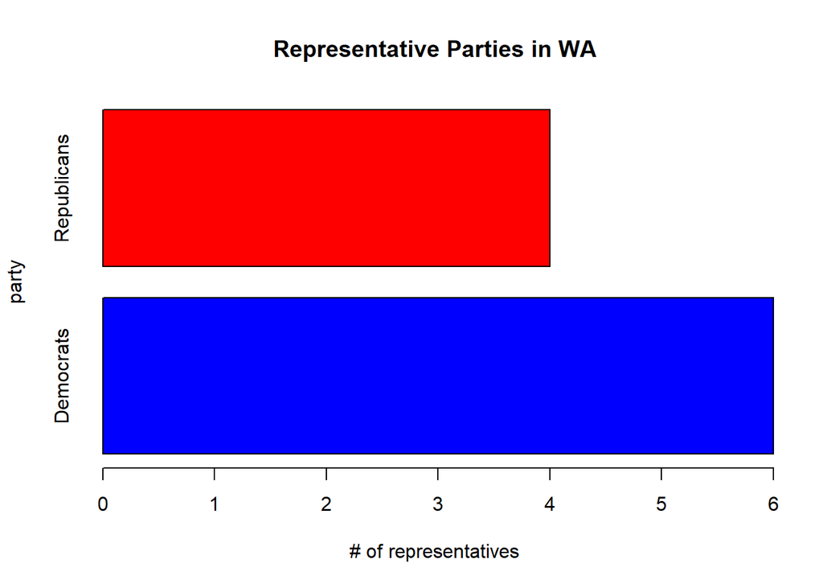

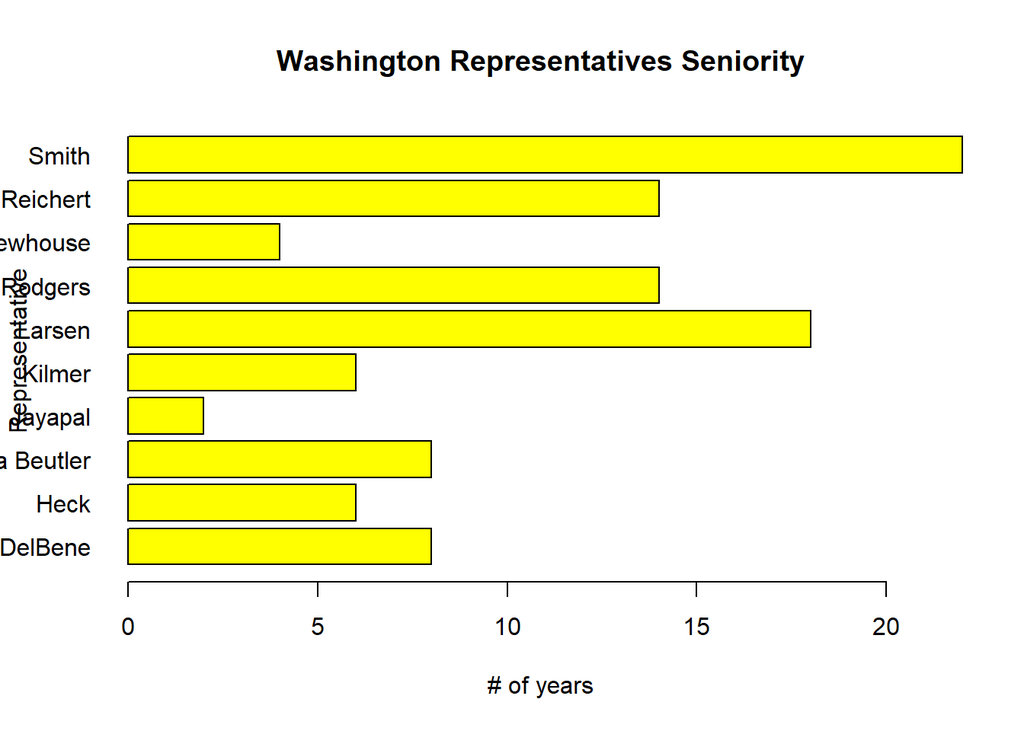

## Pramila Jayapal

Join me on a journey through the life of **Pramila** **Jayapal**. Mrs. Jayapal is a Democratic Representative for the state of Washington. She is 52 years old. Follow her at: RepJayapal. For the last 20 congressional votes, our lovely representative was in accordance with the majority 15% of the time.